# Modern concepts and methods in Macroecology and Biogeography

Day 4: The latitudinal diversity gradient

Patrick Weigelt, Pierre Denelle & Holger Kreft

May 8th, 2024

*back to overview*

**Preparation:** Open your RStudio project and download new data for today from [Stud-IP](https://studip.uni-goettingen.de/dispatch.php/course/files/index/74501b33f332a6d238443bfbd502cc6c?cid=1746ae3fe971afbf90b74e3d64389586) (log in first) and unzip them into your project folder ’/data/. You can use `getwd()` to get your current working directory which is your project folder as long as you do not change it. Please install the following R-packages using `install.packages()` if not done yet:

- `dplyr`
- `classInt`
- `colorRamps`
- `performance`
- `sf`
- `ggplot2`
- `cowplot`

If you want to visualize this tutorial in the viewer inside RStudio (to save space on your screen) run the following chunk of code:

```r
install.packages("rstudioapi") # install an R-package required for this step
dir <- tempfile()
dir.create(dir)
download.file("https://gift.uni-goettingen.de/mcmmb/index.html",
              destfile = file.path(dir, "index.html"))
download.file("https://gift.uni-goettingen.de/mcmmb/Day4.html",
              destfile = file.path(dir, "Day4.html"))
htmlFile <- file.path(dir, "Day4.html")
rstudioapi::viewer(htmlFile)
```

Now you can conveniently copy code from the viewer into your script.

**Load R packages**

```r
library("dplyr")
library("classInt")
library("colorRamps")
library("performance")
library("sf")
library("ggplot2")
library("cowplot")
library("viridis")
```

# 1. Loading palm data set and shapefiles

**Clean up workspace**

```r
rm(list = ls()) # You might want to remove all loaded objects first
```

**Load palm data set**

For today’s exercise, we will continue to use the Neotropical palm data set from [Kreft, H., Sommer, J.H. & Barthlott, W. (2006) The significance of geographic range size for spatial diversity patterns in Neotropical palms. *Ecography*, 29, 21-30](https://onlinelibrary.wiley.com/doi/full/10.1111/j.2005.0906-7590.04203.x).

```r
species <- read.csv("data/palms_species_per_gridcell.csv")
```

**Data inspection**

```r
head(species)
```

```
##   grid_id spp_Id    GENUS EPITHET
## 1   13735    550 Ammandra natalia
## 2   13736    550 Ammandra natalia
## 3   13737    550 Ammandra natalia
## 4   13738    550 Ammandra natalia
## 5   13910    550 Ammandra natalia
## 6   13911    550 Ammandra natalia
```

```r
str(species)
```

```
## 'data.frame':    140860 obs. of  4 variables:
##  $ grid_id: int  13735 13736 13737 13738 13910 13911 13912 13913 13914 14085 ...
##  $ spp_Id : int  550 550 550 550 550 550 550 550 550 550 ...
##  $ GENUS  : chr  "Ammandra" "Ammandra" "Ammandra" "Ammandra" ...
##  $ EPITHET: chr  "natalia" "natalia" "natalia" "natalia" ...
```

Let’s make a new column combining ‘Genus’ and ‘Epithet’

```r
species$species <- paste(species$GENUS,species$EPITHET, sep = " ")
length(unique(species$species)) # number of species
```

```
## [1] 550
```

```r
n_distinct(species$species) # number of species with dplyr
```

```
## [1] 550
```

**Load GIS shapefiles**

```r
# gridcells corresponding to palm distribution data and americas coastline
grid <- st_read("data/30min_grid_select50/30min_grid_select50%.shp")
americas <- st_read("data/americas/americas.shp")
# remember to define the Coordinate Reference System (CRS)
st_crs(grid) <- "+proj=longlat +ellps=WGS84 +no_defs"
st_crs(americas) <- "+proj=longlat +ellps=WGS84 +no_defs"

# have a look at the grid's attribute table
head(grid)
```

```
## Simple feature collection with 6 features and 3 fields
## Geometry type: MULTIPOLYGON
## Dimension:     XY
## Bounding box:  xmin: -115.0007 ymin: 35.5 xmax: -113.0007 ymax: 36.5
## Geodetic CRS:  +proj=longlat +ellps=WGS84 +no_defs
##    ID AREA PORTION                       geometry
## 1 538 0.25     100 MULTIPOLYGON (((-114.0007 3...
## 2 539 0.25     100 MULTIPOLYGON (((-113.5007 3...
## 3 540 0.25     100 MULTIPOLYGON (((-113.0007 3...
## 4 712 0.25     100 MULTIPOLYGON (((-114.5007 3...
## 5 713 0.25     100 MULTIPOLYGON (((-114.0007 3...
## 6 714 0.25     100 MULTIPOLYGON (((-113.5007 3...
```

```r
# change column name of first column ('ID')
colnames(grid)[colnames(grid) == "ID"] <- "grid_id"
head(grid)
```

```
## Simple feature collection with 6 features and 3 fields
## Geometry type: MULTIPOLYGON
## Dimension:     XY
## Bounding box:  xmin: -115.0007 ymin: 35.5 xmax: -113.0007 ymax: 36.5
## Geodetic CRS:  +proj=longlat +ellps=WGS84 +no_defs
##   grid_id AREA PORTION                       geometry
## 1     538 0.25     100 MULTIPOLYGON (((-114.0007 3...
## 2     539 0.25     100 MULTIPOLYGON (((-113.5007 3...
## 3     540 0.25     100 MULTIPOLYGON (((-113.0007 3...
## 4     712 0.25     100 MULTIPOLYGON (((-114.5007 3...
## 5     713 0.25     100 MULTIPOLYGON (((-114.0007 3...
## 6     714 0.25     100 MULTIPOLYGON (((-113.5007 3...
```

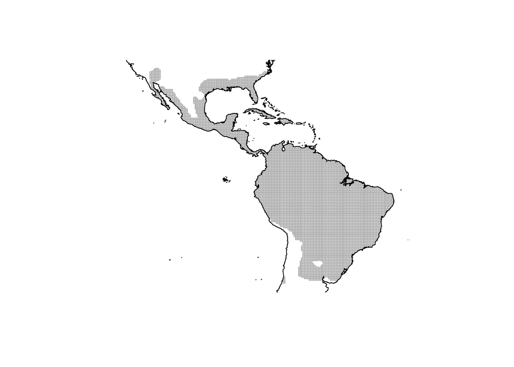

```r
# plot it
plot(st_geometry(grid), border = "darkgrey")
plot(st_geometry(americas), add = TRUE)
```

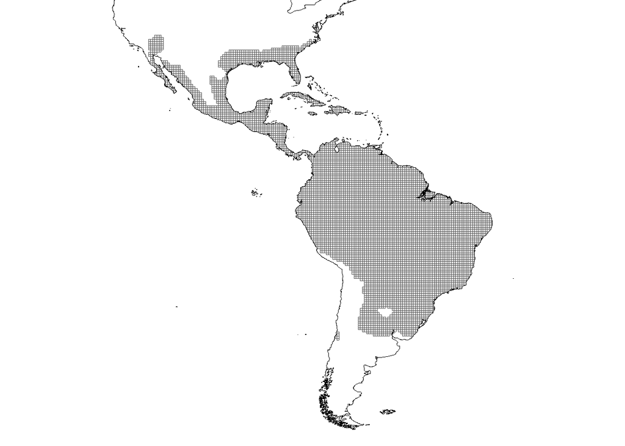

```r
# with ggplot2
ggplot(grid) +
  geom_sf() +
  geom_sf(data = americas, fill = NA, color = "black") +
  ylim(-55, 40) +
  theme_void()
```

**Calculate latitude and longitude from the grid’s polygons**

```r
# convert the polygons to points (mass centroids)
grid_centroids <- st_centroid(grid)

# extract the coordinates of the points
coordinates <- data.frame(st_coordinates(grid_centroids))
str(coordinates)
```

```
## 'data.frame':    6038 obs. of  2 variables:
##  $ X: num  -114 -114 -113 -115 -114 ...
##  $ Y: num  36.2 36.2 36.2 35.7 35.7 ...
```

```r
# add grid_id
coordinates <- data.frame(grid_id = grid_centroids$grid_id,
                          Long = coordinates$X,
                          Lat = coordinates$Y)

# join centroid coordinates to the grid shapefile
grid <- left_join(grid, coordinates, by = "grid_id")
head(grid)
```

```
## Simple feature collection with 6 features and 5 fields
## Geometry type: MULTIPOLYGON
## Dimension:     XY
## Bounding box:  xmin: -115.0007 ymin: 35.5 xmax: -113.0007 ymax: 36.5
## Geodetic CRS:  +proj=longlat +ellps=WGS84 +no_defs
##   grid_id AREA PORTION      Long      Lat                       geometry
## 1     538 0.25     100 -114.2507 36.24999 MULTIPOLYGON (((-114.0007 3...
## 2     539 0.25     100 -113.7507 36.24999 MULTIPOLYGON (((-113.5007 3...
## 3     540 0.25     100 -113.2507 36.24999 MULTIPOLYGON (((-113.0007 3...
## 4     712 0.25     100 -114.7507 35.75000 MULTIPOLYGON (((-114.5007 3...
## 5     713 0.25     100 -114.2507 35.75000 MULTIPOLYGON (((-114.0007 3...
## 6     714 0.25     100 -113.7507 35.75000 MULTIPOLYGON (((-113.5007 3...
```

# 2. Data aggregation (species richness per gridcell)

**Count species per gridcell**

```r
# ?table
species_num <- data.frame(table(species$grid_id))
head(species_num)
```

```
##   Var1 Freq
## 1  538    1
## 2  539    1
## 3  540    1
## 4  712    1
## 5  713    1
## 6  714    1
```

```r
colnames(species_num) <- c("grid_id", "spec_num")
head(species_num)
```

```
##   grid_id spec_num
## 1     538        1
## 2     539        1
## 3     540        1
## 4     712        1
## 5     713        1
## 6     714        1
```

```r
str(species_num)
```

```
## 'data.frame':    6638 obs. of  2 variables:
##  $ grid_id : Factor w/ 6638 levels "538","539","540",..: 1 2 3 4 5 6 7 8 9 10 ...
##  $ spec_num: int  1 1 1 1 1 1 1 1 1 1 ...
```

```r
# change mode of grid_ID to numeric
species_num$grid_id <- as.numeric(as.character(species_num$grid_id))
str(species_num)
```

```
## 'data.frame':    6638 obs. of  2 variables:
##  $ grid_id : num  538 539 540 712 713 714 715 716 885 886 ...
##  $ spec_num: int  1 1 1 1 1 1 1 1 1 1 ...
```

```r
# Species richness distribution
summary(species_num$spec_num)
```

```
##    Min. 1st Qu.  Median    Mean 3rd Qu.    Max.
##    1.00    6.00   16.00   21.22   36.00   82.00
```

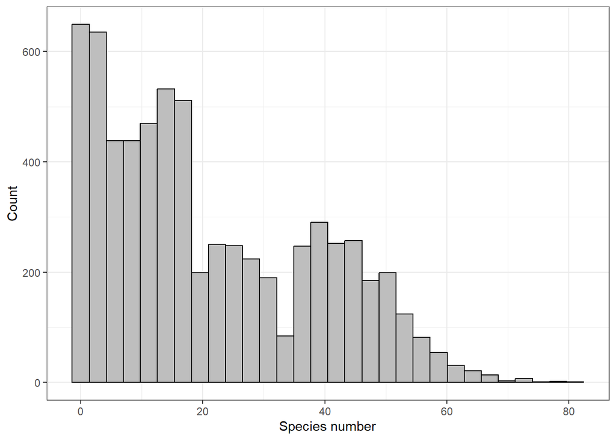

```r
ggplot(species_num, aes(spec_num)) +
  geom_histogram(fill = "grey", color = "black") + # , bins = 30
  labs(x = "Species number", y = "Count") +
  theme_bw()
```

**Join species richness per grid to the shapefile**

```r
grid <- left_join(grid, species_num, by = "grid_id")
head(grid)
```

```
## Simple feature collection with 6 features and 6 fields
## Geometry type: MULTIPOLYGON
## Dimension:     XY
## Bounding box:  xmin: -115.0007 ymin: 35.5 xmax: -113.0007 ymax: 36.5
## Geodetic CRS:  +proj=longlat +ellps=WGS84 +no_defs
##   grid_id AREA PORTION      Long      Lat spec_num
## 1     538 0.25     100 -114.2507 36.24999        1
## 2     539 0.25     100 -113.7507 36.24999        1
## 3     540 0.25     100 -113.2507 36.24999        1
## 4     712 0.25     100 -114.7507 35.75000        1
## 5     713 0.25     100 -114.2507 35.75000        1
## 6     714 0.25     100 -113.7507 35.75000        1
##                         geometry
## 1 MULTIPOLYGON (((-114.0007 3...
## 2 MULTIPOLYGON (((-113.5007 3...
## 3 MULTIPOLYGON (((-113.0007 3...
## 4 MULTIPOLYGON (((-114.5007 3...
## 5 MULTIPOLYGON (((-114.0007 3...
## 6 MULTIPOLYGON (((-113.5007 3...
```

**Make a species richness map**  
With a base R approach.

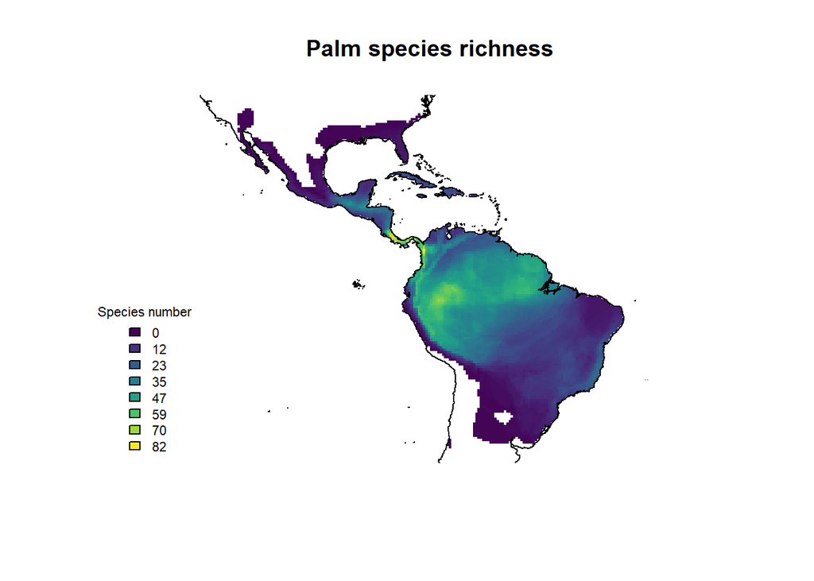

```r
# Defining a color palette
library("viridis")
cols <- viridis(n = 10)
colours <- colorRamp(cols)(grid$spec_num/max(grid$spec_num))
colours <- rgb(colours[,1], colours[,2], colours[,3], maxColorValue = 255)

# Plot
plot(st_geometry(grid),
     col = colours,
     # col = cols[grid$spec_num],
     border = NA,
     main = "Palm species richness")
plot(st_geometry(americas), add = TRUE)

legend_colours <- colorRamp(cols)(seq(0,1,length.out=8))
legend_colours <- rgb(legend_colours[,1], legend_colours[,2],
                      legend_colours[,3], maxColorValue = 255)


legend("bottomleft", # position
       legend = round(seq(0,max(grid$spec_num),length.out=8)),
       title = "Species number",
       fill = legend_colours,
       cex = 0.7,
       bty = "n") # no box around it
```

With a ggplot2 approach.

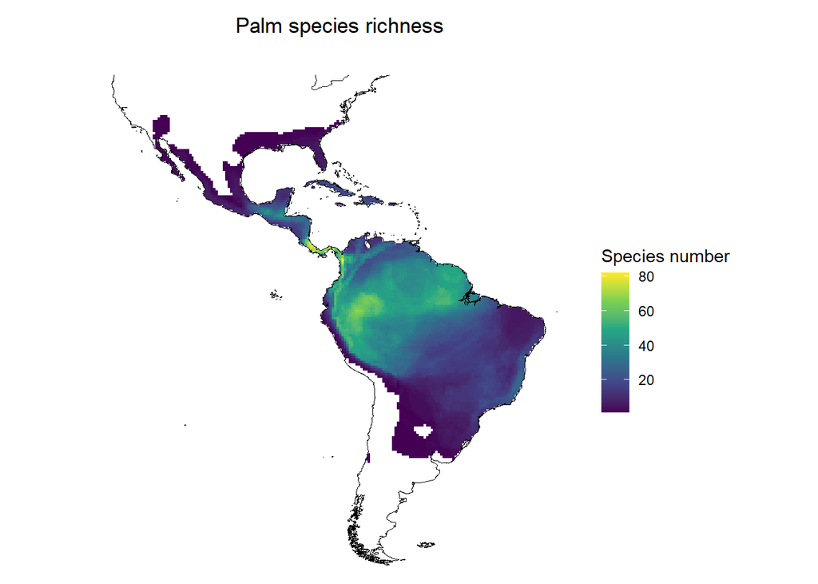

```r
ggplot(grid) +
  geom_sf(color = NA, aes(fill = spec_num)) +
  geom_sf(data = americas, fill = NA, color = "black") +
  labs(title = "Palm species richness") +
  scale_fill_viridis_c("Species number") +
  ylim(-55, 40) +
  theme_void() +
  theme(plot.title = element_text(hjust = 0.5,vjust = 10),
        plot.margin = margin(1,0,0,0, "cm"))
```

*Bonus: custom discrete color scale*

**Bonus**

Plot with intervals instead of a continuous color scale. First with base R.

```r
# Splitting species richness in 10 intervals
my.class.fr <- classIntervals(grid$spec_num, n = 10, style = "equal",
                              dataPrecision = 0) # bin data into n quantiles
my.class.fr
```

```
## style: equal
##   one of 125,595,622,175 possible partitions of this variable into 10 classes
##  [1,10) [10,18) [18,26) [26,34) [34,42) [42,50) [50,58) [58,66) [66,74) [74,82]
##    1844    1215     711     492     657     665     327     100      22       5
```

```r
# Palette of 10 colors
my.pal <- viridis(n = 10)
my.pal
```

```
##  [1] "#440154FF" "#482878FF" "#3E4A89FF" "#31688EFF" "#26828EFF" "#1F9E89FF"
##  [7] "#35B779FF" "#6DCD59FF" "#B4DE2CFF" "#FDE725FF"
```

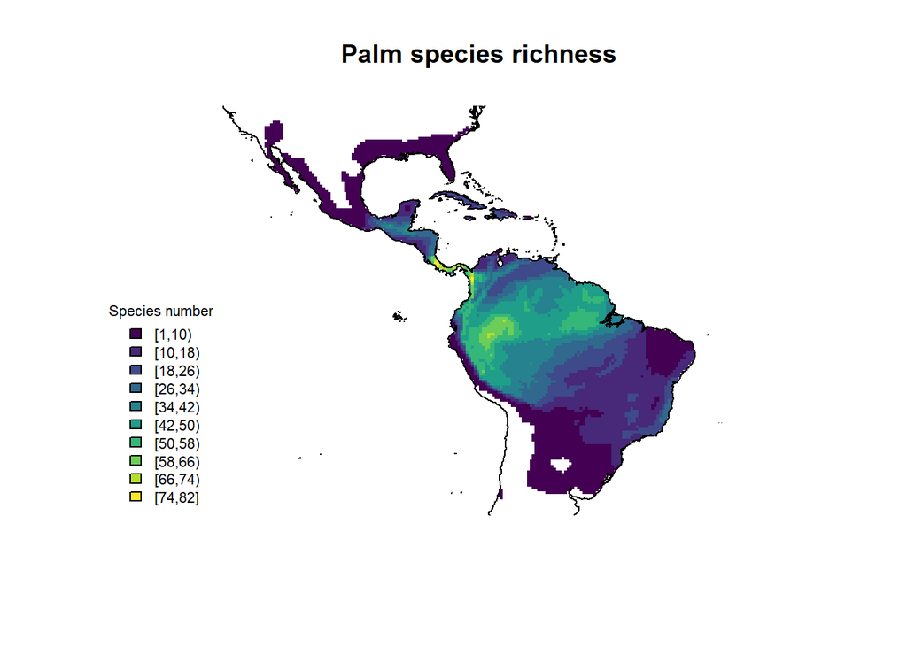

```r
# Create color scheme based on the intervals and the palette
my.col.fr <- findColours(my.class.fr, my.pal) # ramp colors based on classInts

# Plot
plot(st_geometry(grid), col = my.col.fr, border = NA,
     main = "Palm species richness")
plot(st_geometry(americas), add = TRUE)

legend("bottomleft", # position
       legend = names(attr(my.col.fr, "table")),
       title = "Species number",
       fill = attr(my.col.fr, "palette"),
       cex = 0.7,
       bty = "n") # no box around it
```

Second with ggplot2.

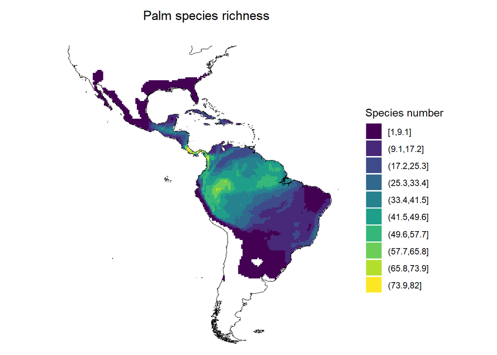

```r
grid$spec_num_cat <- cut_interval(x = grid$spec_num, n = 10)

ggplot(grid) +
  geom_sf(color = NA, aes(fill = spec_num_cat)) +
  geom_sf(data = americas, fill = NA, color = "black") +
  labs(title = "Palm species richness") +
  scale_fill_viridis_d("Species number") +
  ylim(-55, 40) +
  theme_void() +
  theme(plot.title = element_text(hjust = 0.5,vjust = 10),
        plot.margin = margin(1,0,0,0, "cm"))
```

# 3. Exercise

1. How many of the grid cells are located within the Tropics (within +/- 23.433333)?
2. Compare mean species richness per gridcell within and outside the Tropics
3. How many grid cells have more than 20 species and are located South of 17°S? Can you plot them?

# 4. Data aggregation (species richness per latitudinal belt)

```r
# Merging coordinates to species_num data.frame
species_num <- inner_join(species_num, coordinates, by = "grid_id")
range(species_num$Lat)
```

```
## [1] -34.75000  36.24999
```

**Establish latitudinal belts**

```r
belts <- seq(round(min(species_num$Lat),2), round(max(species_num$Lat),2), by = 0.5)
belts
```

```
##   [1] -34.75 -34.25 -33.75 -33.25 -32.75 -32.25 -31.75 -31.25 -30.75 -30.25
##  [11] -29.75 -29.25 -28.75 -28.25 -27.75 -27.25 -26.75 -26.25 -25.75 -25.25
##  [21] -24.75 -24.25 -23.75 -23.25 -22.75 -22.25 -21.75 -21.25 -20.75 -20.25
##  [31] -19.75 -19.25 -18.75 -18.25 -17.75 -17.25 -16.75 -16.25 -15.75 -15.25
##  [41] -14.75 -14.25 -13.75 -13.25 -12.75 -12.25 -11.75 -11.25 -10.75 -10.25
##  [51]  -9.75  -9.25  -8.75  -8.25  -7.75  -7.25  -6.75  -6.25  -5.75  -5.25
##  [61]  -4.75  -4.25  -3.75  -3.25  -2.75  -2.25  -1.75  -1.25  -0.75  -0.25
##  [71]   0.25   0.75   1.25   1.75   2.25   2.75   3.25   3.75   4.25   4.75
##  [81]   5.25   5.75   6.25   6.75   7.25   7.75   8.25   8.75   9.25   9.75
##  [91]  10.25  10.75  11.25  11.75  12.25  12.75  13.25  13.75  14.25  14.75
## [101]  15.25  15.75  16.25  16.75  17.25  17.75  18.25  18.75  19.25  19.75
## [111]  20.25  20.75  21.25  21.75  22.25  22.75  23.25  23.75  24.25  24.75
## [121]  25.25  25.75  26.25  26.75  27.25  27.75  28.25  28.75  29.25  29.75
## [131]  30.25  30.75  31.25  31.75  32.25  32.75  33.25  33.75  34.25  34.75
## [141]  35.25  35.75  36.25
```

```r
length(belts)
```

```
## [1] 143
```

**Species richness of one particular latitudinal belt**  
Select gridcells based on latitude

```r
species_num[which(species_num$Lat > -25.5 & species_num$Lat < -25),
            "spec_num"]
```

```
##  [1]  1  1  1  1  1  1  1  2  3  3  3  3  3  3  5  6  6  9  7  8  8  7  7  7  7
## [26]  8  8  8  8 11 16 17 14 11
```

Select gridcells based on latitude taking from belts object

```r
belts[20]
```

```
## [1] -25.25
```

```r
species_num[which(species_num$Lat > belts[20] - 0.25 &
                    species_num$Lat < belts[20] + 0.25), "spec_num"]
```

```
##  [1]  1  1  1  1  1  1  1  2  3  3  3  3  3  3  5  6  6  9  7  8  8  7  7  7  7
## [26]  8  8  8  8 11 16 17 14 11
```

```r
mean(species_num[which(species_num$Lat > belts[20] - 0.25 &
                         species_num$Lat < belts[20] + 0.25), "spec_num"])
```

```
## [1] 6.029412
```

**Species richness across all latitudinal belts (‘for loop approach’)**

```r
# for-loop example
for (i in 1:5){
  print(i)
  Sys.sleep(1)
}
```

```
## [1] 1
## [1] 2
## [1] 3
## [1] 4
## [1] 5
```

```r
# create an empty vector for the mean species counts
species_per_belt_loop <- NA

# loop trough the latitudinal belts and calculate the mean species richness
for (i in 1:length(belts)){
  belt_subset <- species_num[which(species_num$Lat > belts[i] - 0.25 &
                                     species_num$Lat < belts[i] + 0.25),
                             "spec_num"]
  species_per_belt_loop[i] <- mean(belt_subset)
}
```

**Species richness across all latitudinal belts (‘apply a function approach’)**

```r
# function example
myFunction <- function(x){
  if (x > 5) message("Hello")
}
myFunction(5)
myFunction(6)
```

```
## Hello
```

```r
# define the function
species_per_belt_function <- function(x){
  mean(species_num[which(species_num$Lat > x - 0.25 &
                           species_num$Lat < x + 0.25), "spec_num"])
}

# apply the function to one latitudinal belt
species_per_belt_function(-15.75)
```

```
## [1] 16.92537
```

```r
# apply the function to all belts
species_per_belt_apply <- sapply(belts, function(x)
  mean(species_num$spec_num[which(species_num$Lat > x - 0.25 &
                                    species_num$Lat < x + 0.25)]))

species_per_belt_apply <- sapply(belts, species_per_belt_function)
```

**Species richness across all latitudinal belts (‘dplyr approach’)**

```r
# create belt column
species_num$belt <- round(species_num$Lat*100/25)*25/100 # round at a quarter
species_num <- group_by(species_num, belt)
species_per_belt_dplyr <- summarize(species_num, richness = mean(spec_num))
species_per_belt_dplyr <- species_per_belt_dplyr$richness
species_num <- ungroup(species_num)
```

**Compare loop, apply and dplyr approach**

```r
# compare loop and apply approach
all(species_per_belt_apply == species_per_belt_loop)
```

```
## [1] TRUE
```

```r
all(species_per_belt_apply == species_per_belt_dplyr)
```

```
## [1] TRUE
```

```r
species_per_belt <- species_per_belt_apply
```

**Save the results**

```r
save(species_num, file = "data/species_num.RData")
save(belts, species_per_belt, file = "data/species_num_belts.RData")
write.csv(species_num, "data/species_num.csv", row.names = FALSE)
```

# 5. The latitudinal gradient model (LDG)

In case you had problems creating the `species_num` and `species_per_belt` data.frames you can now load our provided *.Rdata files

```r
load("data/species_num.RData")
load("data/species_num_belts.RData")
```

**Gridcell level**

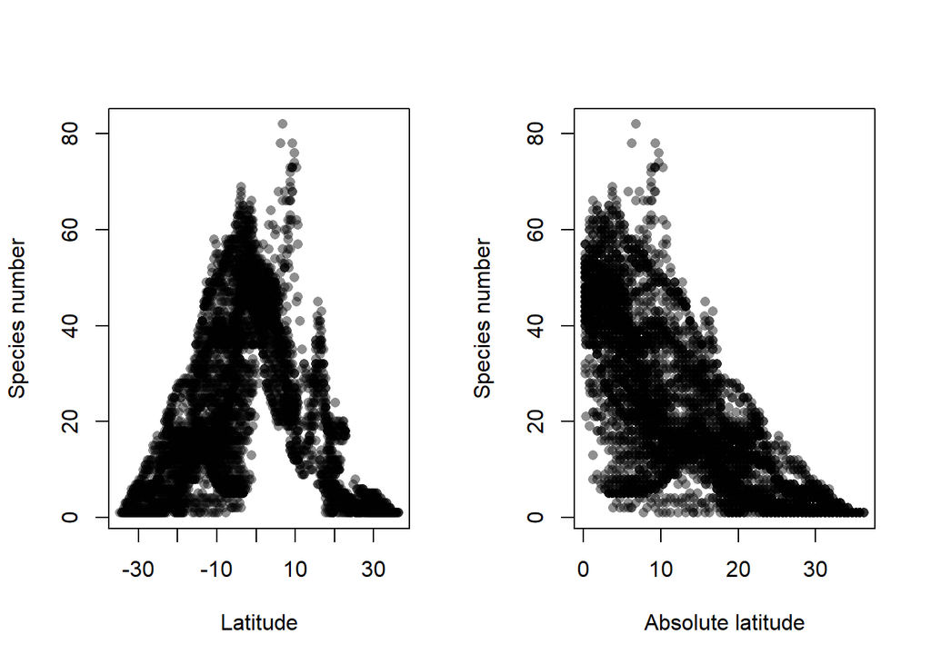

```r
par(mfrow = c(1, 2))
plot(species_num$Lat, species_num$spec_num,
     xlab = "Latitude", ylab = "Species number",
     pch = 16, col = "#00000070")
plot(abs(species_num$Lat), species_num$spec_num,
     xlab = "Absolute latitude", ylab = "Species number",
     pch = 16, col = "#00000070")
```

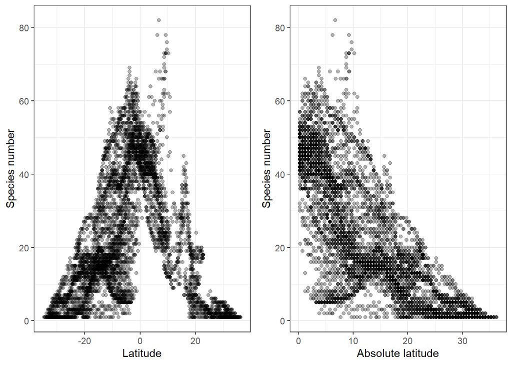

```r
# for color codes, see here: https://htmlcolorcodes.com/

# With ggplot2
plot_grid(
  ggplot(species_num, aes(Lat, spec_num)) +
    geom_point(color = "black", alpha = 0.3) +
    labs(x = "Latitude", y = "Species number") +
    theme_bw(),
  ggplot(species_num, aes(abs(Lat), spec_num)) +
    geom_point(color = "black", alpha = 0.3) +
    labs(x = "Absolute latitude", y = "Species number") +
    theme_bw()
)
```

What could be the reason for the triangular relationship?

**Linear model of species richness ~ latitude**

```r
# run a linear model for palm species richness in dependence on latitude
model1 <- lm(species_num$spec_num ~ abs(species_num$Lat))
summary(model1)
```

```
##
## Call:
## lm(formula = species_num$spec_num ~ abs(species_num$Lat))
##
## Residuals:
##     Min      1Q  Median      3Q     Max
## -34.000  -6.952   0.901   6.441  50.045
##
## Coefficients:
##                      Estimate Std. Error t value Pr(>|t|)
## (Intercept)          41.30384    0.25271  163.44   <2e-16 ***
## abs(species_num$Lat) -1.38503    0.01498  -92.44   <2e-16 ***
## ---
## Signif. codes:  0 '***' 0.001 '**' 0.01 '*' 0.05 '.' 0.1 ' ' 1
##
## Residual standard error: 11.17 on 6036 degrees of freedom
## Multiple R-squared:  0.5861, Adjusted R-squared:  0.586
## F-statistic:  8546 on 1 and 6036 DF,  p-value: < 2.2e-16
```

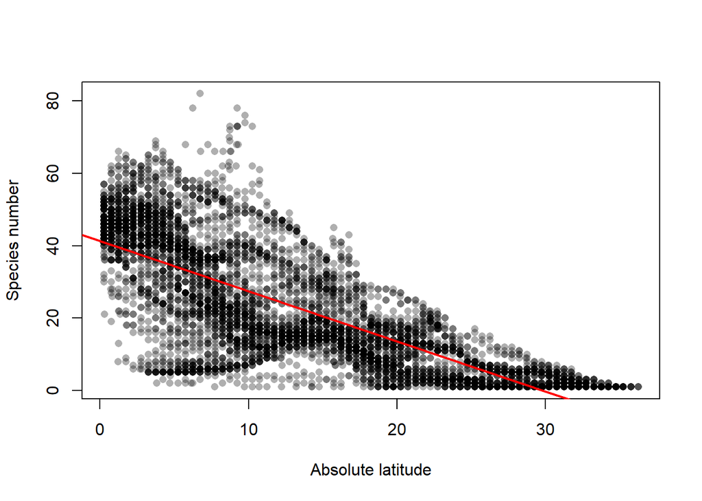

```r
par(mfrow = c(1, 1))
plot(abs(species_num$Lat), species_num$spec_num,
     xlab = "Absolute latitude", ylab = "Species number",
     pch = 16, col = "#00000050")
abline(model1, col = "red", lwd = 2)
```

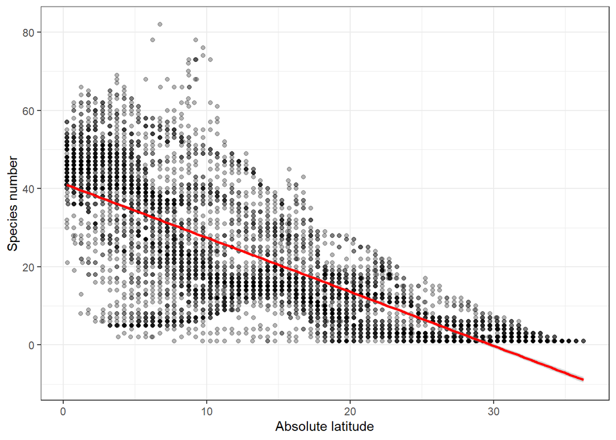

```r
# With ggplot2
ggplot(species_num, aes(abs(Lat), spec_num)) +
  geom_point(color = "black", alpha = 0.3) +
  stat_smooth(method = "lm", color = "red") +
  labs(x = "Absolute latitude", y = "Species number") +
  theme_bw()
```

**Latitudinal belts**

```r
model2 <- lm(species_per_belt ~ abs(belts))
summary(model2)
```

```
##
## Call:
## lm(formula = species_per_belt ~ abs(belts))
##
## Residuals:
##    Min     1Q Median     3Q    Max
## -9.059 -3.580 -0.834  3.622 10.044
##
## Coefficients:
##             Estimate Std. Error t value Pr(>|t|)
## (Intercept) 40.49252    0.70119   57.75   <2e-16 ***
## abs(belts)  -1.30523    0.03395  -38.45   <2e-16 ***
## ---
## Signif. codes:  0 '***' 0.001 '**' 0.01 '*' 0.05 '.' 0.1 ' ' 1
##
## Residual standard error: 4.195 on 141 degrees of freedom
## Multiple R-squared:  0.9129, Adjusted R-squared:  0.9123
## F-statistic:  1478 on 1 and 141 DF,  p-value: < 2.2e-16
```

```r
model3 <- lm(species_per_belt ~ abs(belts) + I(abs(belts)^2))
summary(model3)
```

```
##
## Call:
## lm(formula = species_per_belt ~ abs(belts) + I(abs(belts)^2))
##
## Residuals:
##     Min      1Q  Median      3Q     Max
## -7.1598 -1.2409  0.1004  1.0354 13.0752
##
## Coefficients:
##                  Estimate Std. Error t value Pr(>|t|)
## (Intercept)     46.994483   0.753758   62.35   <2e-16 ***
## abs(belts)      -2.393983   0.097118  -24.65   <2e-16 ***
## I(abs(belts)^2)  0.030401   0.002625   11.58   <2e-16 ***
## ---
## Signif. codes:  0 '***' 0.001 '**' 0.01 '*' 0.05 '.' 0.1 ' ' 1
##
## Residual standard error: 3.009 on 140 degrees of freedom
## Multiple R-squared:  0.9555, Adjusted R-squared:  0.9549
## F-statistic:  1504 on 2 and 140 DF,  p-value: < 2.2e-16
```

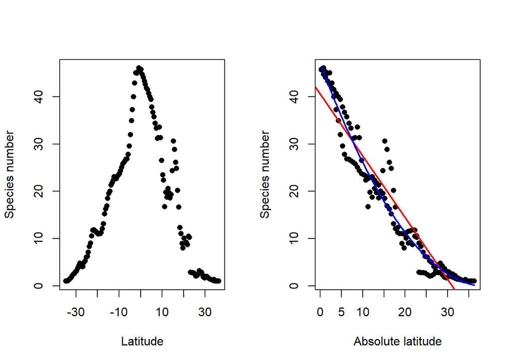

```r
# Plot
par(mfrow = c(1, 2))
plot(belts, species_per_belt,
     xlab = "Latitude", ylab = "Species number", pch = 16)
plot(abs(belts), species_per_belt,
     xlab = "Absolute latitude", ylab = "Species number",pch = 16)
abline(model2, col = "red", lwd = 2)
points(abs(belts), predict(model3), type = "l", col = "blue", lwd = 2)
```

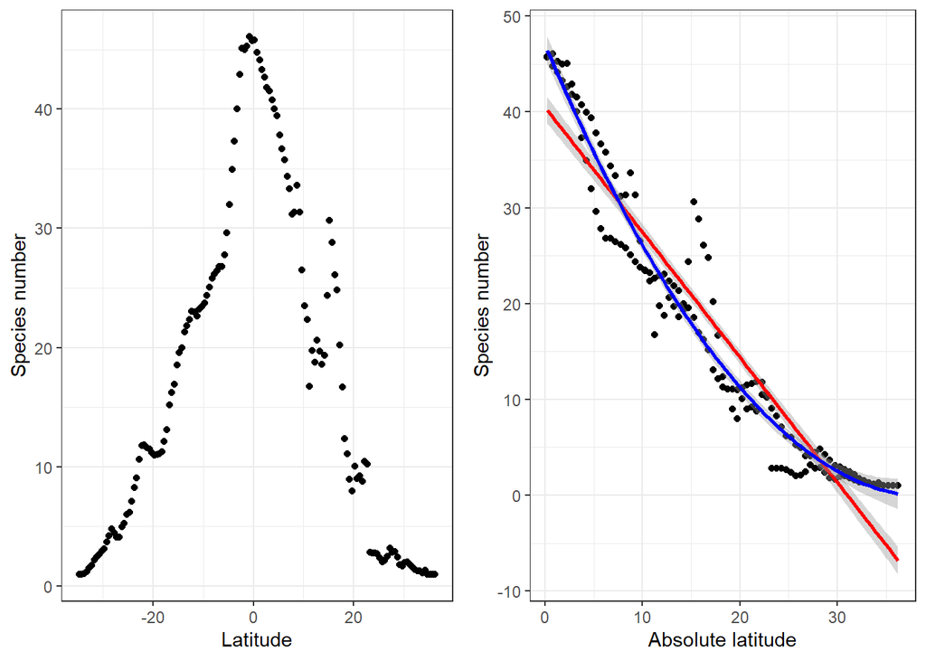

```r
# With ggplot2
belt_sp <- data.frame(belts = belts,
                      spec_num = species_per_belt)

plot_grid(
  ggplot(belt_sp, aes(belts, spec_num)) +
    geom_point(color = "black") +
    labs(x = "Latitude", y = "Species number") +
    theme_bw(),
  ggplot(belt_sp, aes(abs(belts), spec_num)) +
    geom_point(color = "black") +
    stat_smooth(method = "lm", formula = y ~ abs(x),
                color = "red") +
    stat_smooth(method = "lm", formula = y ~ abs(x) + I(abs(x)^2),
                color = "blue") +
    labs(x = "Absolute latitude", y = "Species number") +
    theme_bw()
)
```

Let’s also assess model performance using the performance package to calculate commonly used indices, such as R<sup>2</sup>, AIC, RMSE, etc.

```r
AIC(model2, model3)
```

```
##        df      AIC
## model2  3 819.8933
## model3  4 725.8151
```

```r
compare_performance(model3, model2)
```

```
## # Comparison of Model Performance Indices
##
## Name   | Model | AIC (weights) | AICc (weights) | BIC (weights) |    R2 | R2 (adj.) |  RMSE | Sigma
## ---------------------------------------------------------------------------------------------------
## model3 |    lm | 725.8 (>.999) |  726.1 (>.999) | 737.7 (>.999) | 0.956 |     0.955 | 2.977 | 3.009
## model2 |    lm | 819.9 (<.001) |  820.1 (<.001) | 828.8 (<.001) | 0.913 |     0.912 | 4.166 | 4.195
```